# Cellranger Mapping QC

Paula Soler-Vila

10 March 2021

# 1 Introduction

The objective of this notebook is to perform a basic quality control (QC) analysis of the mapping performed with [Cellranger](https://support.10xgenomics.com/single-cell-atac/software/pipelines/latest/what-is-cell-ranger-atac).

The expected values (EV) included in the notebook are obtained from this [technical_note](https://assets.ctfassets.net/an68im79xiti/Cts31zFxXFXVwJ1lzU3Pc/fe66343ffd3039de73ecee6a1a6f5b7b/CG000202_TechnicalNote_InterpretingCellRangerATACWebSummaryFiles_Rev-A.pdf).

# 2 Pre-processing

## 2.1 Load packages

```r
library(ggplot2)
library(ggpubr)
library(plyr)
library(reshape2)
library(data.table)
library(knitr)
library(kableExtra)
```

## 2.2 Parameters

```r
path_to_ATAC <- here::here("scATAC-seq/results/tables/cellranger_mapping/cellranger_mapping_metrics_atac.csv")
path_to_proj_metadata <- here::here("scATAC-seq/1-cellranger_mapping/data/tonsil_atlas_metadata_atac.csv")
```

## 2.3 Load data

```r
qc_samples <- read.csv(path_to_ATAC)
metadata <- read.csv(path_to_proj_metadata)
```

```r
qc_samples <- merge(metadata[,c(2,4,5)], qc_samples, by = "gem_id")
```

```r
knitr::kable(qc_samples, row.names = TRUE) %>%
  kable_styling(
    bootstrap_options = c("striped"),
    full_width = T,
    font_size = 12
  ) %>%
  scroll_box(height = "300px")
```

|  | gem_id | library_name | donor_id | annotated_cells | bc_q30_bases_fract | cellranger.atac_version | cells_detected | frac_cut_fragments_in_peaks | frac_fragments_nfr | frac_fragments_nfr_or_nuc | frac_fragments_nuc | frac_fragments_overlapping_peaks | frac_fragments_overlapping_targets | frac_mapped_confidently | frac_waste_chimeric | frac_waste_duplicate | frac_waste_lowmapq | frac_waste_mitochondrial | frac_waste_no_barcode | frac_waste_non_cell_barcode | frac_waste_overall_nondup | frac_waste_total | frac_waste_unmapped | median_fragments_per_cell | median_per_cell_unique_fragments_at_30000_RRPC | median_per_cell_unique_fragments_at_50000_RRPC | num_fragments | r1_q30_bases_fract | r2_q30_bases_fract | … |
| --- | --- | --- | --- | --- | --- | --- | --- | --- | --- | --- | --- | --- | --- | --- | --- | --- | --- | --- | --- | --- | --- | --- | --- | --- | --- | --- | --- | --- | --- | --- |
| 1 | aks0q3tw_lsr4h73j | BCLL_8_T_FACS | BCLL-8-T | 6717 | 0.8948042 | 1.2.0 | 6717 | 0.7257834 | 0.5472286 | 0.9012909 | 0.3540623 | 0.7412773 | 0.7833529 | 0.3494334 | 0.0031413 | 0.0813598 | 0.0234437 | 0.0022219 | 0.0213551 | 0.4500887 | 0.7198395 | 0.8011993 | 0.2195888 | 3339.0 | 2206.365 | NA | 167670830 | 0.9466974 | 0.9410558 | … |
| 2 | dhqzxpdk_h8em75r9 | BCLL_12_T | BCLL-12-T | 6244 | 0.8696613 | 1.2.0 | 6244 | 0.4923115 | 0.5967472 | 0.9464746 | 0.3497274 | 0.5098465 | 0.6956077 | 0.6844528 | 0.0048545 | 0.0903358 | 0.0372740 | 0.0046757 | 0.0444331 | 0.4929319 | 0.6472180 | 0.7375538 | 0.0630487 | 5292.0 | 3054.092 | 4742.607 | 178702950 | 0.9455460 | 0.9423521 | … |
| 3 | fnpetv1y_agr9h7v4 | BCLL_9_T_FACS | BCLL-9-T | 7164 | 0.8865307 | 1.2.0 | 7164 | 0.6783310 | 0.5260771 | 0.8978277 | 0.3717506 | 0.6928251 | 0.7594494 | 0.5028532 | 0.0047776 | 0.1494920 | 0.0381712 | 0.0101802 | 0.0212989 | 0.3400078 | 0.5798483 | 0.7293403 | 0.1654126 | 4046.5 | 2576.860 | 3787.893 | 196853176 | 0.9397705 | 0.9362940 | … |
| 4 | jbp85ve3_3179tpob | BCLL_9_T | BCLL-9-T | 3612 | 0.8887994 | 1.2.0 | 3612 | 0.2837703 | 0.6280703 | 0.9338411 | 0.3057707 | 0.3004984 | 0.5892465 | 0.6830870 | 0.0045902 | 0.1197789 | 0.0390125 | 0.0078794 | 0.0211442 | 0.5441375 | 0.6798266 | 0.7996055 | 0.0630628 | 10787.5 | 2339.871 | 3715.704 | 353741802 | 0.9366631 | 0.9340069 | … |
| 5 | jmjpvq6z_fr6c4nyp | BCLL_10_T | BCLL-10-T | 6157 | 0.8784005 | 1.2.0 | 6157 | 0.4716604 | 0.3964072 | 0.9180236 | 0.5216164 | 0.4903269 | 0.6724432 | 0.7462978 | 0.0032068 | 0.1062895 | 0.0314410 | 0.0018553 | 0.0208837 | 0.5452063 | 0.6371774 | 0.7434669 | 0.0345844 | 6244.0 | 3112.109 | 4932.543 | 202665970 | 0.9383474 | 0.9388454 | … |
| 6 | lacrul5e_67e3wsyf | BCLL_13_T | BCLL-13-T | 3452 | 0.8562378 | 1.2.0 | 3452 | 0.4407586 | 0.6079594 | 0.9404463 | 0.3324869 | 0.4585786 | 0.6749509 | 0.6897716 | 0.0050483 | 0.1142576 | 0.0366578 | 0.0069747 | 0.0514990 | 0.5119774 | 0.6637047 | 0.7779622 | 0.0515475 | 8972.5 | 2808.334 | 4377.907 | 221333748 | 0.9451797 | 0.9438240 | … |
| 7 | lzj8c3xo_ytz0xw8m | BCLL_6_T | BCLL-6-T | 2042 | 0.8753589 | 1.2.0 | 2042 | 0.5070785 | 0.5841875 | 0.9263258 | 0.3421383 | 0.5241960 | 0.7150116 | 0.6758412 | 0.0046042 | 0.1304155 | 0.0353566 | 0.0100624 | 0.0446941 | 0.5088401 | 0.6548143 | 0.7852299 | 0.0512570 | 10507.5 | 2560.361 | 4040.094 | 177880808 | 0.9441977 | 0.9443175 | … |
| 8 | m7maqeew_gt2mrtf3 | BCLL_14_T_ATAC | BCLL-14-T | 4792 | 0.8989238 | 1.2.0 | 4792 | 0.7845776 | 0.5892214 | 0.9095258 | 0.3203045 | 0.7957060 | 0.8437654 | 0.8732575 | 0.0078310 | 0.3361539 | 0.0617598 | 0.0048708 | 0.0161090 | 0.1014355 | 0.2014203 | 0.5375742 | 0.0094142 | 6108.5 | 4877.966 | NA | 100747124 | 0.9542793 | 0.9529444 | … |
| 9 | sy59df1i_56bwpc10 | BCLL_8_T | BCLL-8-T | 5055 | 0.8795414 | 1.2.0 | 5055 | 0.5697281 | 0.4400192 | 0.9113211 | 0.4713018 | 0.5889213 | 0.7263104 | 0.6178068 | 0.0034120 | 0.0900166 | 0.0312596 | 0.0045070 | 0.0231727 | 0.5148060 | 0.6286825 | 0.7186991 | 0.0515251 | 5386.0 | 3391.215 | 5224.607 | 131277280 | 0.9355983 | 0.9314623 | … |
| 10 | u51p7uvm_s5fhku31 | BCLL_10_T_FACS | BCLL-10-T | 4026 | 0.8801543 | 1.2.0 | 4026 | 0.6836160 | 0.4304005 | 0.8571635 | 0.4267630 | 0.7014042 | 0.7781722 | 0.5784632 | 0.0035152 | 0.1990302 | 0.0324499 | 0.0036631 | 0.0210990 | 0.4055919 | 0.5822178 | 0.7812481 | 0.1158987 | 7011.0 | 3179.130 | 4755.994 | 176532371 | 0.9430902 | 0.9445326 | … |
| 11 | vcan8qd9_sr5u40yg | BCLL_11_T_FACS | BCLL-11-T | 4332 | 0.8821805 | 1.2.0 | 4332 | 0.6599436 | 0.4626812 | 0.8731640 | 0.4104828 | 0.6773343 | 0.7743509 | 0.5131103 | 0.0035075 | 0.1557782 | 0.0299406 | 0.0087843 | 0.0215466 | 0.4836095 | 0.6644061 | 0.8201843 | 0.1170176 | 4531.5 | 2216.230 | 3296.805 | 170934789 | 0.9428297 | 0.9454462 | … |
| 12 | xazsjcvt_kzi9e2rf | BCLL_15_T_ATAC | BCLL-15-T | 3696 | 0.8974435 | 1.2.0 | 3696 | 0.6465260 | 0.4768757 | 0.8819319 | 0.4050562 | 0.6629857 | 0.7918493 | 0.8499945 | 0.0049653 | 0.2241764 | 0.0431229 | 0.0031281 | 0.0162198 | 0.4474242 | 0.5205142 | 0.7446906 | 0.0056539 | 5782.0 | 2557.606 | 3755.735 | 181480062 | 0.9512431 | 0.9498741 | … |
| 13 | yja17lfh_kdslhq0g | BCLL_11_T | BCLL-11-T | 6873 | 0.8780811 | 1.2.0 | 6873 | 0.3310638 | 0.4558902 | 0.8902835 | 0.4343934 | 0.3500105 | 0.6073575 | 0.7366171 | 0.0036220 | 0.1161636 | 0.0404997 | 0.0103084 | 0.0205003 | 0.5240662 | 0.6318879 | 0.7480515 | 0.0328913 | 4866.0 | 2501.579 | 3921.326 | 222415271 | 0.9385211 | 0.9382643 | … |

# 3 Overall statistics

## 3.1 Estimated number of cells

Let us start by plotting the estimated number of cells per library. Note this this number will differ a lot from the final number of cells after applying future QC filters:

```r
number_cells <- qc_samples[, c("library_name", "annotated_cells")]
```

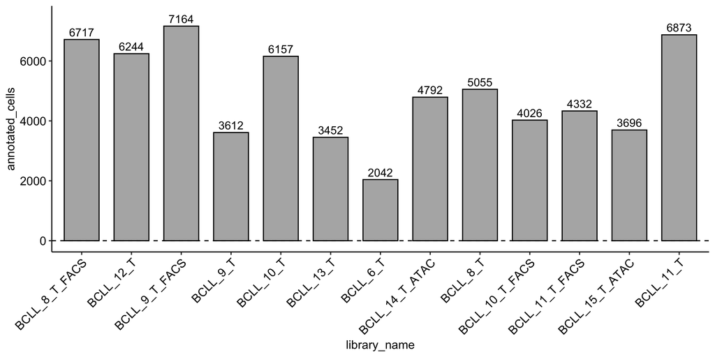

```r
ggbarplot(number_cells,
  x = "library_name",
  y = "annotated_cells",
  fill = "gray70",
  label = TRUE,
  legend = NULL,
  position = position_dodge(0.9),
  font.label = list(color = "white", size = 10, vjust = 0.4),
  ggtheme = theme_pubr()
) +
  geom_hline(yintercept = 0.65, linetype = 2, color = "black") +
  theme_pubr(x.text.angle = 45) + ylim(c(0, max(number_cells$annotated_cells) + 300))
```

## 3.2 Median number of fragments per cell

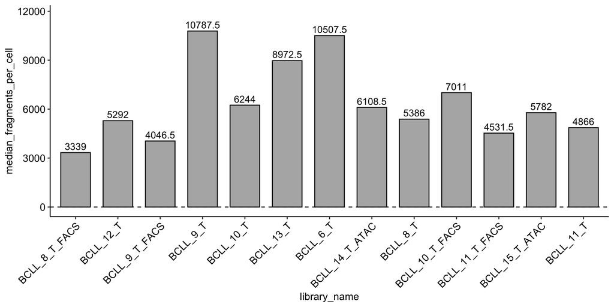

```r
ggbarplot(qc_samples,
  x = "library_name",
  y = "median_fragments_per_cell",
  fill = "gray70",
  label = TRUE,
  position = position_dodge(0.9),
  font.label = list(color = "white", size = 10, vjust = 0.4),
  ggtheme = theme_pubr()
) +
  geom_hline(yintercept = 0.65, linetype = 2, color = "black") +
  theme_pubr(x.text.angle = 45) + ylim(c(0, max(qc_samples$median_fragments_per_cell) + 1000))
```

# 4 Sequencing

## 4.1 Total number of read pairs

The suggested sequencing depth value is ~25,000 read pairs per cell.

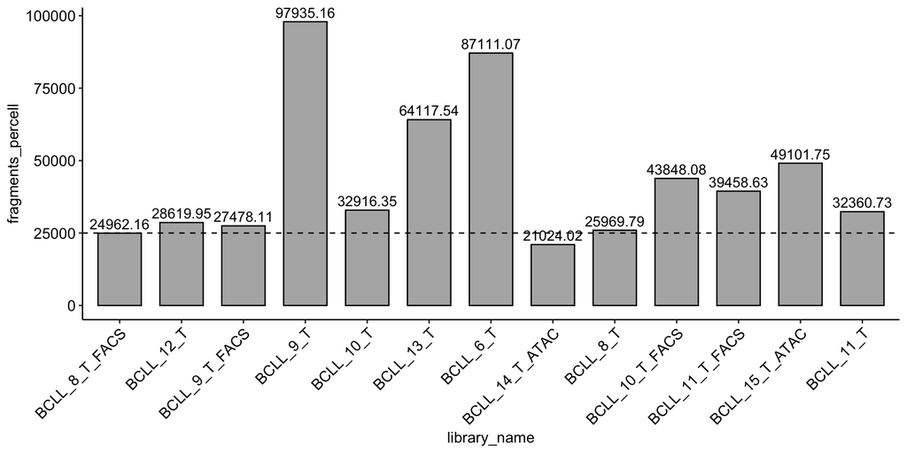

```r
qc_samples$fragments_percell <- round(qc_samples$num_fragments/qc_samples$cells_detected,2)

ggbarplot(qc_samples,
  x = "library_name",
  y = "fragments_percell",
  fill = "gray70",
  label = TRUE,
  font.label = list(color = "white", size = 9, vjust = 0.4),
  ggtheme = theme_pubr()
) +
  geom_hline(yintercept = 25000, linetype = 2, color = "black") +
  theme_pubr(x.text.angle = 45)
```

## 4.2 Percentatge of Q30 bases

To quantify the quality of our sequenced libraries prior to mapping, we will leverage the “Q30” variables in our dataset.

```r
q30.melt <- melt((qc_samples[, c("library_name", "r1_q30_bases_fract", "r2_q30_bases_fract", "bc_q30_bases_fract")]))
q30.melt$value <- round(q30.melt$value, 2)
```

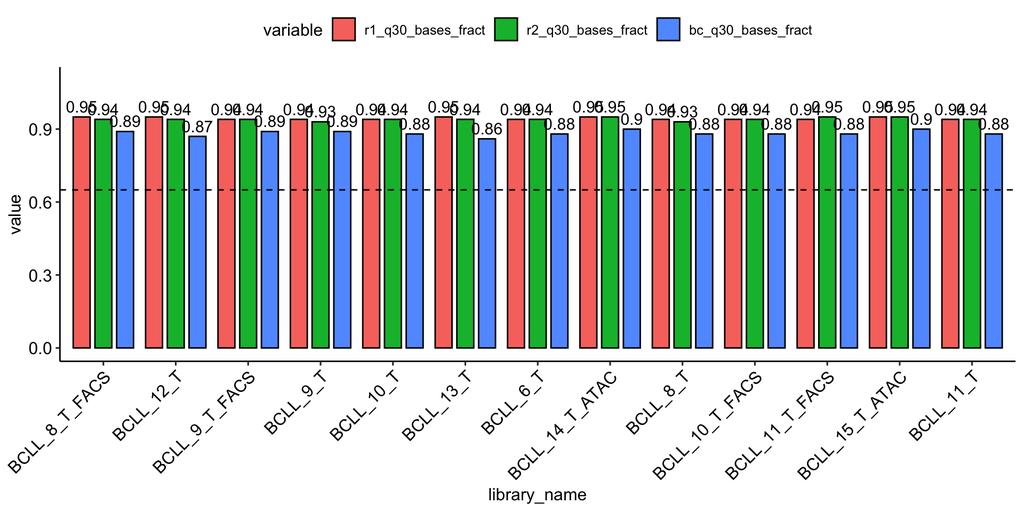

```r
ggbarplot(q30.melt,
  x = "library_name",
  y = "value",
  fill = "variable",
  label = TRUE,
  position = position_dodge(0.9),
  font.label = list(color = "white", size = 9, vjust = 0.4),
  ggtheme = theme_pubr()
) +
  geom_hline(yintercept = 0.65, linetype = 2, color = "black") +
  theme_pubr(x.text.angle = 45) + ylim(c(0, 1.1))
```

# 5 Insert size metrics

- frac_fragments_nfr => Fragments (< 147 bp) in nucleosome-free regions.
- frac_fragments_nuc => Fragments (147 ~ 294 bp) flanking a single nucleosome.

The fraction of fragments in nucleosome-free regions is expected to be the highest proportion (> 40% EV, red dashed line) as compared to mononucleosome and dinucleosome regions.

```r
data_insert_size <- qc_samples[, c("library_name", "frac_fragments_nfr", "frac_fragments_nuc")]
data_insert_size.melt <- melt(data_insert_size)
data_insert_size.melt$value <- round(data_insert_size.melt$value, 2)
```

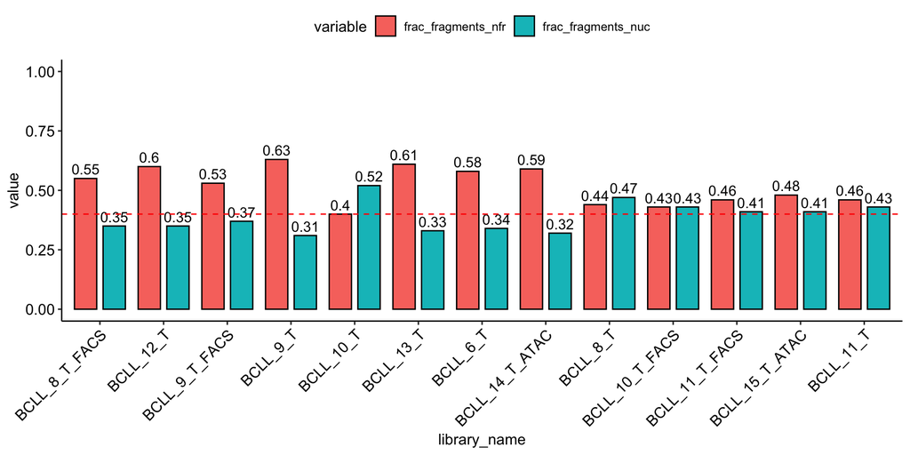

```r
ggbarplot(data_insert_size.melt,
  x = "library_name", label = TRUE,
  y = "value", fill = "variable", position = position_dodge(0.9)
) +
  theme_pubr(x.text.angle = 45) + geom_hline(yintercept = 0.40, linetype = 2, color = "red") + ylim(c(0, 1))
```

# 6 Targeting Metrics

## 6.1 Overlapping of fragments

Fraction of fragments that overlap with any targeted regions such as TSS, DNase HS, enhancer or promoter regions ( > 55% EV, red dashed line), and the fraction of transposition events in peaks in cell barcodes ( > 25% EV, blue dashed line).

```r
data_overlap <- qc_samples[, c("library_name", "frac_fragments_overlapping_targets", "frac_fragments_overlapping_peaks")]
data_overlap.melt <- melt(data_overlap)
data_overlap.melt$value <- round(data_overlap.melt$value, 2)
```

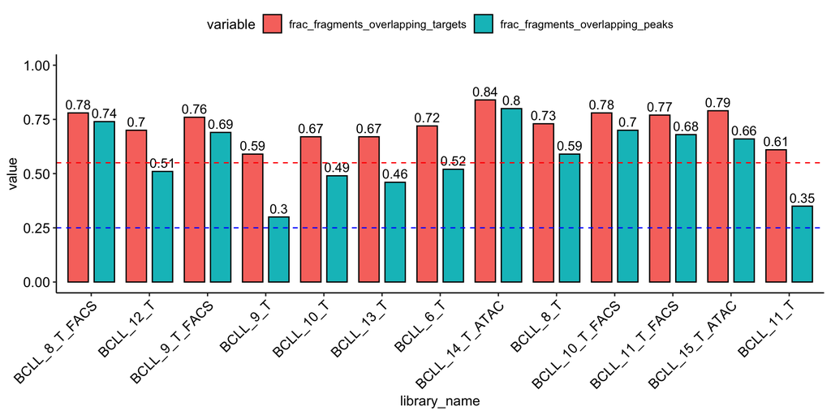

```r
ggbarplot(data_overlap.melt,
  x = "library_name", label = TRUE,
  y = "value", fill = "variable", position = position_dodge(0.9)
) +
  theme_pubr(x.text.angle = 45) +
  geom_hline(yintercept = 0.55, linetype = 2, color = "red") +
  geom_hline(yintercept = 0.25, linetype = 2, color = "blue") + ylim(c(0, 1))
```

## 6.2 Transcription Start Site (TSS)

It is expected to obtain a large enrichment around TSS (> 5% EV, red dashed line), as these regions are known to show a high degree of chromatin accessibility compared to the flanking regions.

```r
data_tss <- qc_samples[, c("library_name", "tss_enrichment_score")]
data_tss.melt <- melt(data_tss)
data_tss.melt$value <- round(data_tss.melt$value, 2)
```

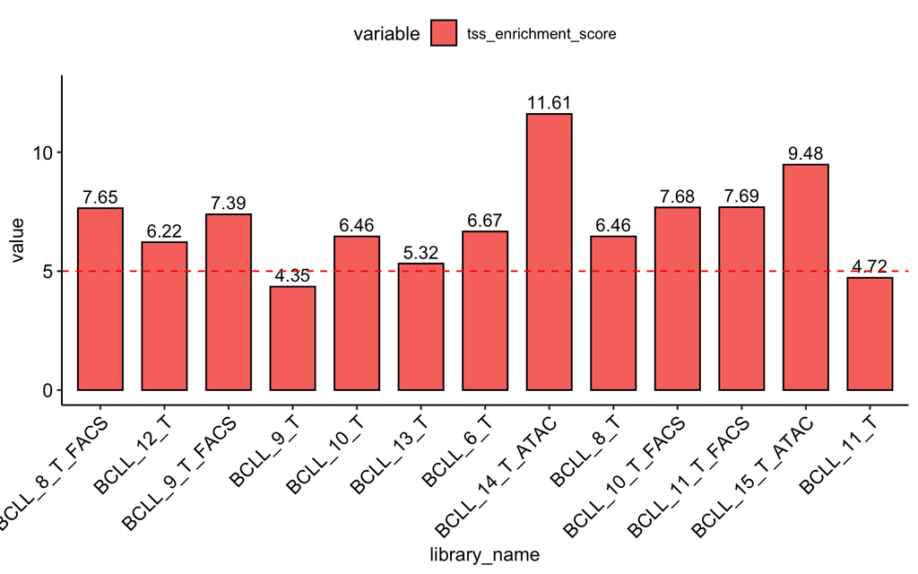

```r
ggbarplot(data_tss.melt,
  x = "library_name", label = TRUE,
  y = "value", fill = "variable", position = position_dodge(0.9)
) +
  theme_pubr(x.text.angle = 45) + geom_hline(yintercept = 5, linetype = 2, color = "red") + ylim(c(0, max(data_tss.melt$value) + 1))
```